# Survival analysis using R: Kaplan-Meier Survival Curve

Dr. Wan Nor Arifin

Updated: 15 December 2025

# 1 Introduction

1. A statistical method to analyze:
   - outcome: time to event (e.g. death, recurrence etc).
   - (comparison) predictors/independent variables: categorical variables.
2. It is concerned with survival probability at specific time points over a time interval (follow-up period), e.g. five year survival etc.
3. Basically, the *interval survival* at time $t$ is as follows,
   $$Interval\ survival,p_t = {Survivors,\ n_t -
   Deaths,\ e_t \over Survivor,\ n_t}$$
   The survival is usually represented by *cumulative survival* until time $t$,
   $$Cumulative\ survival, s_t =
   p_0p_1p_2...p_{t-1}$$
4. In follow-up study over a period of time, not all subjects will experience event (e.g. not everyone die in 5 years). The subjects are called *censored* observations. In survival analysis, this censored observations are taken into account.

# 2 Kaplan-Meier survival curve in a group

Acute myeloid leukemia data (Miller, 1997).

| time | status | x |
| --- | --- | --- |
| 9 | 1 | Maintained |
| 13 | 1 | Maintained |
| 13 | 0 | Maintained |
| 18 | 1 | Maintained |
| 23 | 1 | Maintained |
| 28 | 0 | Maintained |
| 31 | 1 | Maintained |
| 34 | 1 | Maintained |
| 45 | 0 | Maintained |
| 48 | 1 | Maintained |
| 161 | 0 | Maintained |
| 5 | 1 | Nonmaintained |
| 5 | 1 | Nonmaintained |
| 8 | 1 | Nonmaintained |
| 8 | 1 | Nonmaintained |
| 12 | 1 | Nonmaintained |
| 16 | 0 | Nonmaintained |
| 23 | 1 | Nonmaintained |
| 27 | 1 | Nonmaintained |
| 30 | 1 | Nonmaintained |
| 33 | 1 | Nonmaintained |
| 43 | 1 | Nonmaintained |
| 45 | 1 | Nonmaintained |

Load the required packages. Make sure you have all these in your computer.

```r
# library
library(survival)
library(survminer)
library(epiDisplay)
library(coin)
```

We are going to use a built-in dataset in `survival` package, namely `aml`. We assign it to `acute` data object to avoid confusion with the built-in dataset name.

```r
# data
?aml  # about the dataset
acute = aml
acute
```

```
#>    time status             x
#> 1     9      1    Maintained
#> 2    13      1    Maintained
#> 3    13      0    Maintained
#> 4    18      1    Maintained
#> 5    23      1    Maintained
#> 6    28      0    Maintained
#> 7    31      1    Maintained
#> 8    34      1    Maintained
#> 9    45      0    Maintained
#> 10   48      1    Maintained
#> 11  161      0    Maintained
#> 12    5      1 Nonmaintained
#> 13    5      1 Nonmaintained
#> 14    8      1 Nonmaintained
#> 15    8      1 Nonmaintained
#> 16   12      1 Nonmaintained
#> 17   16      0 Nonmaintained
#> 18   23      1 Nonmaintained
#> 19   27      1 Nonmaintained
#> 20   30      1 Nonmaintained
#> 21   33      1 Nonmaintained
#> 22   43      1 Nonmaintained
#> 23   45      1 Nonmaintained
```

Explore the data,

```r
codebook(acute)
```

```
#>
#>
#>
#> time      :
#>  obs. mean   median  s.d.   min.   max.
#>  23   29.478 23      31.72  5      161
#>
#>  ==================
#> status    :
#>  obs. mean   median  s.d.   min.   max.
#>  23   0.783  1       0.422  0      1
#>
#>  ==================
#> x     :
#>               Frequency Percent
#> Maintained           11    47.8
#> Nonmaintained        12    52.2
#>
#>  ==================
```

```r
table(acute$status)  # number of events
```

```
#>
#>  0  1
#>  5 18
```

Generate survival curve data for plotting by `survfit()`.

```r
sur_aml = survfit(Surv(time, status) ~ 1, data = acute)
```

View median survival time and its 95% confidence interval from `sur_aml`,

```r
sur_aml  # median survival time = 27 (95%CI: 18, 45)
```

```
#> Call: survfit(formula = Surv(time, status) ~ 1, data = acute)
#>
#>       n events median 0.95LCL 0.95UCL
#> [1,] 23     18     27      18      45
```

and the details of the survival curve data,

```r
summary(sur_aml)
```

```
#> Call: survfit(formula = Surv(time, status) ~ 1, data = acute)
#>
#>  time n.risk n.event survival std.err lower 95% CI upper 95% CI
#>     5     23       2   0.9130  0.0588       0.8049        1.000
#>     8     21       2   0.8261  0.0790       0.6848        0.996
#>     9     19       1   0.7826  0.0860       0.6310        0.971
#>    12     18       1   0.7391  0.0916       0.5798        0.942
#>    13     17       1   0.6957  0.0959       0.5309        0.912
#>    18     14       1   0.6460  0.1011       0.4753        0.878
#>    23     13       2   0.5466  0.1073       0.3721        0.803
#>    27     11       1   0.4969  0.1084       0.3240        0.762
#>    30      9       1   0.4417  0.1095       0.2717        0.718
#>    31      8       1   0.3865  0.1089       0.2225        0.671
#>    33      7       1   0.3313  0.1064       0.1765        0.622
#>    34      6       1   0.2761  0.1020       0.1338        0.569
#>    43      5       1   0.2208  0.0954       0.0947        0.515
#>    45      4       1   0.1656  0.0860       0.0598        0.458
#>    48      2       1   0.0828  0.0727       0.0148        0.462
```

Note the `survival` column for $s_t$.

Now plot Kaplan-Meier survival curve,

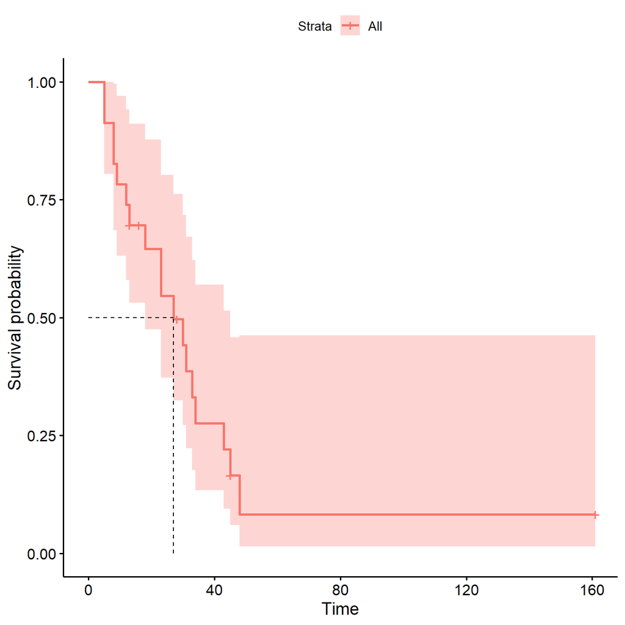

```r
ggsurvplot(sur_aml, surv.median.line = "hv")
```

# 3 Comparing Kaplan-Meier curves between groups

Glioma data for histology grade 4 patients (Grana et al., 2002).

|  | time | event | group |
| --- | --- | --- | --- |
| 12 | 43 | FALSE | RIT |
| 13 | 20 | TRUE | RIT |
| 14 | 14 | TRUE | RIT |
| 15 | 36 | FALSE | RIT |
| 16 | 59 | FALSE | RIT |
| 17 | 31 | TRUE | RIT |
| 18 | 14 | TRUE | RIT |
| 19 | 36 | TRUE | RIT |
| 26 | 8 | TRUE | Control |
| 27 | 8 | TRUE | Control |
| 28 | 11 | TRUE | Control |
| 29 | 12 | TRUE | Control |
| 30 | 15 | TRUE | Control |
| 31 | 5 | TRUE | Control |
| 32 | 8 | TRUE | Control |
| 33 | 8 | TRUE | Control |
| 34 | 6 | TRUE | Control |
| 35 | 14 | TRUE | Control |
| 36 | 13 | TRUE | Control |
| 37 | 25 | TRUE | Control |

## 3.1 KM for two groups

Now we use the built-in data in `coin` package, namely `glioma`. We assign it to `gli` data object to avoid confusion with the built-in dataset name.

```r
# data
?glioma  # about the dataset
gli = glioma
str(gli)
```

```
#> 'data.frame':    37 obs. of  7 variables:
#>  $ no.      : int  1 2 3 4 5 6 7 8 9 10 ...
#>  $ age      : int  41 45 48 54 40 31 53 49 36 52 ...
#>  $ sex      : Factor w/ 2 levels "Female","Male": 1 1 2 2 1 2 2 2 2 2 ...
#>  $ histology: Factor w/ 2 levels "GBM","Grade3": 2 2 2 2 2 2 2 2 2 2 ...
#>  $ group    : Factor w/ 2 levels "Control","RIT": 2 2 2 2 2 2 2 2 2 2 ...
#>  $ event    : logi  TRUE FALSE FALSE FALSE FALSE TRUE ...
#>  $ time     : int  53 28 69 58 54 25 51 61 57 57 ...
```

For this analysis, we only need the data for `GBM` subgroup under `histology`,

```r
gli4 = subset(gli, histology == "GBM")  # grade 4 glioma
str(gli4)
```

```
#> 'data.frame':    20 obs. of  7 variables:
#>  $ no.      : int  12 13 14 15 16 17 18 19 7 8 ...
#>  $ age      : int  55 70 39 40 47 58 40 36 32 70 ...
#>  $ sex      : Factor w/ 2 levels "Female","Male": 1 2 1 1 1 2 1 2 1 2 ...
#>  $ histology: Factor w/ 2 levels "GBM","Grade3": 1 1 1 1 1 1 1 1 1 1 ...
#>  $ group    : Factor w/ 2 levels "Control","RIT": 2 2 2 2 2 2 2 2 1 1 ...
#>  $ event    : logi  FALSE TRUE TRUE FALSE FALSE TRUE ...
#>  $ time     : int  43 20 14 36 59 31 14 36 8 8 ...
```

Expore the data,

```r
codebook(gli4)
```

```
#>
#>
#>
#> no.   :
#>  obs. mean   median  s.d.   min.   max.
#>  20   13.7   14      3.466  7      19
#>
#>  ==================
#> age   :
#>  obs. mean   median  s.d.   min.   max.
#>  20   53.9   52.5    14.436 32     83
#>
#>  ==================
#> sex   :
#>        Frequency Percent
#> Female        10      50
#> Male          10      50
#>
#>  ==================
#> histology     :
#>        Frequency Percent
#> GBM           20     100
#> Grade3         0       0
#>
#>  ==================
#> group     :
#>         Frequency Percent
#> Control        12      60
#> RIT             8      40
#>
#>  ==================
#> event     :
#>       Frequency Percent
#> FALSE         3      15
#> TRUE         17      85
#>
#>  ==================
#> time      :
#>  obs. mean   median  s.d.   min.   max.
#>  20   19.3   14      14.55  5      59
#>
#>  ==================
```

Now, we generate survival curve data,

```r
sur_gli4 = survfit(Surv(time, event) ~ group, data = gli4)
```

then view the median (95% CI),

```r
sur_gli4  # median survival times/group, 0.95UCL cannot be estimated
```

```
#> Call: survfit(formula = Surv(time, event) ~ group, data = gli4)
#>
#>                n events median 0.95LCL 0.95UCL
#> group=Control 12     12    9.5       8      NA
#> group=RIT      8      5   33.5      20      NA
```

and the details of the survival curve data,

```r
summary(sur_gli4)
```

```
#> Call: survfit(formula = Surv(time, event) ~ group, data = gli4)
#>
#>                 group=Control
#>  time n.risk n.event survival std.err lower 95% CI upper 95% CI
#>     5     12       1   0.9167  0.0798       0.7729        1.000
#>     6     11       1   0.8333  0.1076       0.6470        1.000
#>     8     10       4   0.5000  0.1443       0.2840        0.880
#>    11      6       1   0.4167  0.1423       0.2133        0.814
#>    12      5       1   0.3333  0.1361       0.1498        0.742
#>    13      4       1   0.2500  0.1250       0.0938        0.666
#>    14      3       1   0.1667  0.1076       0.0470        0.591
#>    15      2       1   0.0833  0.0798       0.0128        0.544
#>    25      1       1   0.0000     NaN           NA           NA
#>
#>                 group=RIT
#>  time n.risk n.event survival std.err lower 95% CI upper 95% CI
#>    14      8       2    0.750   0.153        0.503        1.000
#>    20      6       1    0.625   0.171        0.365        1.000
#>    31      5       1    0.500   0.177        0.250        1.000
#>    36      4       1    0.375   0.171        0.153        0.917
```

Now we plot the `sur_gli4` data,

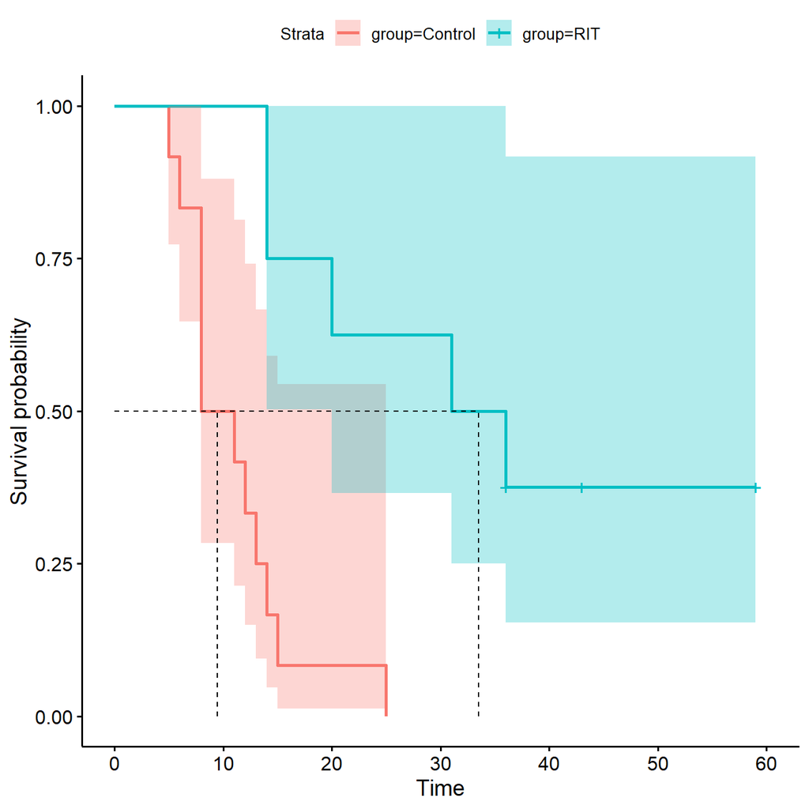

```r
ggsurvplot(sur_gli4, conf.int = T, surv.median.line = "hv")
```

## 3.2 Log-rank test comparing two groups

Now, we compare statistically the survival curves of the groups by log-rank test,

```r
survdiff(Surv(time, event) ~ group, data = gli4)
```

```
#> Call:
#> survdiff(formula = Surv(time, event) ~ group, data = gli4)
#>
#>                N Observed Expected (O-E)^2/E (O-E)^2/V
#> group=Control 12       12     5.93      6.23      12.6
#> group=RIT      8        5    11.07      3.33      12.6
#>
#>  Chisq= 12.6  on 1 degrees of freedom, p= 4e-04
```

# 4 Exercises

1. Analyze gli data for histology == “Grade3”.

```r
gli3 = subset(gli, histology == "Grade3")
```

2. Again, analyze using `aml` data from `survival` package. This time compare the groups (`x` variable in the dataset).
3. Use dataset from “Practice Datasets” folder.

# References

Arifin, W. N., Sarimah, A., Norsa’adah, B., Majdi, Y. N., Siti-Azrin, A. H., Imran, M. K., … Naing, L. (2016). Reporting statistical results in medical journals. *The Malaysian Journal of Medical Sciences: MJMS*, *23*(5), 1.

Chongsuvivatwong, V. (2022). *epiDisplay: Epidemiological data display package*. Retrieved from https://CRAN.R-project.org/package=epiDisplay

Fox, J., & Weisberg, S. (2019). *An R companion to applied regression* (Third). Thousand Oaks CA: Sage. Retrieved from https://www.john-fox.ca/Companion/

Fox, J., Weisberg, S., & Price, B. (2024). *Car: Companion to applied regression*. Retrieved from https://r-forge.r-project.org/projects/car/

Grana, C., Chinol, M., Robertson, C., Mazzetta, C., Bartolomei, M., De Cicco, C., … Paganelli, G. (2002). Pretargeted adjuvant radioimmunotherapy with yttrium-90-biotin in malignant glioma patients: A pilot study. *British Journal of Cancer*, *86*(2), 207.

Hothorn, T. (2025). *TH.data: TH’s data archive*. Retrieved from https://CRAN.R-project.org/package=TH.data

Hothorn, T., Hornik, K., van de Wiel, M. A., & Zeileis, A. (2006). A Lego system for conditional inference. *The American Statistician*, *60*(3), 257–263. https://doi.org/10.1198/000313006X118430

Hothorn, T., Hornik, K., van de Wiel, M. A., & Zeileis, A. (2008). Implementing a class of permutation tests: The coin package. *Journal of Statistical Software*, *28*(8), 1–23. https://doi.org/10.18637/jss.v028.i08

Hothorn, T., Winell, H., Hornik, K., van de Wiel, M. A., & Zeileis, A. (2023). *Coin: Conditional inference procedures in a permutation test framework*. Retrieved from http://coin.r-forge.r-project.org

Kassambara, A., Kosinski, M., & Biecek, P. (2025). *Survminer: Drawing survival curves using ggplot2*. Retrieved from https://rpkgs.datanovia.com/survminer/index.html

Miller, R. G. (1997). *Survival analysis*. John Wiley & Sons.

Musa, K. I., Mansor, W. N. A. W., & Hanis, T. M. (2023). *Data analysis in medicine and health using r*. New York: Chapman; Hall/CRC. Retrieved from https://www.taylorfrancis.com/books/mono/10.1201/9781003296775/data-analysis-medicine-health-using-kamarul-imran-musa-wan-arifin-wan-mansor-tengku-muhammad-hanis

Rizopoulos, D. (2017). EP03: Survival analysis in R companion. Retrieved September 12, 2018, from http://www.drizopoulos.com/courses/emc/ep03_%20survival%20analysis%20in%20r%20companion#survival-probabilities-from-cox-models

Terry M. Therneau, & Patricia M. Grambsch. (2000). *Modeling survival data: Extending the Cox model*. New York: Springer.

Therneau, T. M. (2024). *Survival: Survival analysis*. Retrieved from https://github.com/therneau/survival

Woodward, M. (2013). *Epidemiology: Study design and data analysis*. Boca Raton, FL, USA: CRC Press.